# Assignment_5_Petrella

Riccardo Petrella

2024-02-19

Plot $u_t$ against $y_t$ for a DCS-t-location, a Beta-t-GARCH and a Beta-t-GARCH processes for different values of $\nu = 3, 10, 200$.

In order to visualize better how the response of the score changes for different extreme observations I’m going to use the shiny library to make the plot interactive.

1. For a DCS-t location model we are going to define a function for the martingale difference sequence, the function that generates numbers from a t-student distribution and a function that simulate the model using the function provided in the R-score files uploaded in virtuale.

where $v_t = y_t - \mu{t|t-1}$

```r
martingale_diff_u_t <- function(y, mu_t, varsigma, nu){

  u_t <- c((1 / (1 + (y - mu_t)^2/(nu*varsigma)) * (y - mu_t)))

  return(u_t)
}
```

Now we are going to define the function for the the random generating numbers

```r
uSTDT_rnd <- function(n, mu, varsigma, nu) {

  z <- rt(n, df = nu)
  y <- numeric()
  for(i in 1:n){
    y[i] <- c(mu + z[i]* sqrt(varsigma) )
  }

  return(y)
}
```

Here we define the function that simulate the process, the innovations factor and the updated filters. In particular recall that

$\mu_{t+1 | t} = \omega + \phi\mu_{t|t-1} + ku_t$

```r
uDCS_t_model_simulator <- function(T, omega, phi, k, varsigma, nu){

  ###Define the Processes
  y   <- array(data = NA, dim = c(T) )

  ###Define Dynamic Location and Innovations
  mu_t <- array(data = NA, dim = c(T))
  u_t  <- array(data = NA, dim = c(T-1))

  ###Initial value for the recursion
  mu_t[1]   <- omega

  ###Generate the first observations of the process
  y[1]   <- uSTDT_rnd(1, mu_t[1], varsigma, nu)

  ###Dynamics
  for (t in 2:T) {

    ###Factor Innovations
    u_t[t-1] <- martingale_diff_u_t(y[t-1], mu_t[t-1], varsigma, nu)

    ###Updating Filters
    mu_t[t]   <- omega + phi * (mu_t[t-1] - omega) + k * u_t[t-1]

    ###Generate the observations of the processes
    y[t] <- uSTDT_rnd(1, mu_t[t], varsigma, nu)
  }

  ###Make List
  out <- list(y_t_gen          = as.ts(y),
              Dynamic_Location = as.ts(mu_t),
              Innovation_u_t   = as.ts(u_t))

  return(out)
}
```

Now we can simulate the process using some initial values

```r
T <- 800       # number of observations

# Parameters
omega <- 0
phi <- 0.8
k <- 0.8
varsigma <- 2.5


# Values of nu to iterate over
library(shiny)

ui <- fluidPage(
  sliderInput("nu_slider", "nu", min = 3, max = 200, value = 3), # Slider to select the value of nu
  plotOutput("dcs_plot") # Placeholder for the plot
)

server <- function(input, output) {
  output$dcs_plot <- renderPlot({
    nu <- input$nu_slider # Get the current value of nu from the slider
    simu <- uDCS_t_model_simulator(T, omega, phi, k, varsigma, nu) # Run the simulation with the selected nu value

    # Generate the y_t time series
    y_t <- simu$y_t_gen

    # Plot the y_t time series with a title indicating the current nu value
    ts.plot(y_t, main = paste("DCS simulation for the time varying location (nu =", nu, ")"))

    # Obtain the u_t transformation
    u_t <- simu$Innovation_u_t
    lines(u_t, col = "red")

  })
}

shinyApp(ui, server) #it may be required to open the plot in a browser
```

Shiny applications not supported in static R Markdown documents

```r
#Uncomment the lines below to see just the three iterations

#nu_values <- c(3, 10, 200)

#for (nu in nu_values) {
  #simu <- uDCS_t_model_simulator(T, omega, phi, k, varsigma, nu)

  # y_t
  #y_t <- simu$y_t_gen
  #dim(y_t)
  #ts.plot(y_t, main = paste("DCS simulation for the time varying location (nu =", nu, ")"))

  # u_t
  #u_t <- simu$Innovation_u_t
  #dim(u_t)
  #lines(u_t, col = "red")
#}
```

As we can see as $\nu$ increases, $u_t$ show a more pronounced response to extreme observations. When $\nu$ is smaller, the extreme observations has a lower impact on the score.

2. For a Beta-t-GARCH as we did before we are going to introduce the three functions but with different equations.

Here the martingale difference sequence that we are going to use is the following: $u_t = \frac{(\nu + 1) * y^2}{(\nu-2)*\sigma_t + y^2} -1$

```r
mds_scale <- function(y, mu, sigma_t, nu){
  u_t <- c((nu+1)*y^2 / ((nu-2)*sigma_t + y^2) - 1)
  return(u_t)
}
```

Now the data generating process of $y_t$ from a $t$-Student distribution, recall that for a Beta-t-GARCH process $y_t = \sigma_{t|t-1} * z_t$

```r
uSTDT_rnd_scale_beta <- function(n, sigma_t, nu) {
  z <- rt(n, df = nu)
  y <- numeric()
  for(i in 1:n){
    y[i] <- c(z[i]* sqrt(sigma_t))
  }
  return(y)
}
```

And finally the simulator for the scale. Recall that $\sigma_{t|t-1}^2 = \omega + \phi * \sigma_{t-1|t-2}^2 + k * \sigma_{t-1|t-2}^2 * u_{t-1}$

```r
beta_simulator_scale <- function(T, omega, phi, k, mu, nu){

  ###Define the Processes
  y   <- array(data = NA, dim = c(T) )

  ###Define Dynamic Scale and Innovations
  sigma_t <- array(data = NA, dim = c(T))
  u_t  <- array(data = NA, dim = c(T-1))

  ###Initial value for the recursion
  sigma_t[1]   <- omega

  ###Generate the first observations of the process
  y[1]   <- uSTDT_rnd_scale_beta(1, sigma_t[1], nu)

  ###Dynamics
  for (t in 2:T) {

    ###Factor Innovations
    u_t[t-1] <- mds_scale(y[t-1], mu, sigma_t[t-1], nu)

    ###Updating Filters
    sigma_t[t]   <- omega + phi * (sigma_t[t-1]^2) + k * (sigma_t[t-1]^2) * u_t[t-1]

    ###Generate the observations of the processes
    y[t] <- uSTDT_rnd_scale_beta(1, sigma_t[t], nu)
  }
  ######################
  ####### OUTPUT #######
  ######################

  ###Make List
  out <- list(y_t_gen          = as.ts(y),
              Dynamic_scale = as.ts(sigma_t),
              Innovation_u_t   = as.ts(u_t))

  return(out)
}
```

Now we can simulate the process with initial values of the parameters

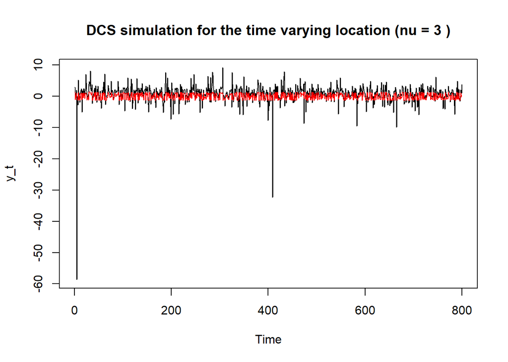

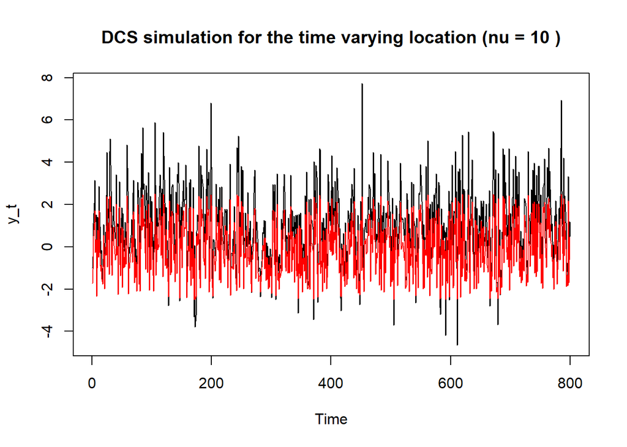

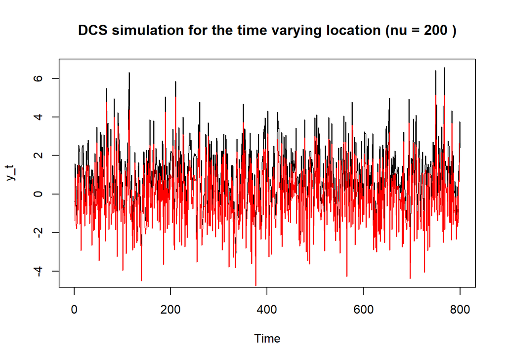

```r
T <- 800       # number of observations
# Parameters
omega <- 1
phi <- 0.5
k <- 0.2
mu <- 0

#uncomment those lines if you want so see the slider

#import shiny to make interactive visualizations
#library(shiny)

#ui <- fluidPage(
  #sliderInput("nu_slider", "nu", min = 3, max = 200, value = 3), # Slider to select the value of nu
  #plotOutput("beta_t_plot") # Placeholder for the plot
#)

#server <- function(input, output) {
#  output$beta_t_plot <- renderPlot({
#    nu <- input$nu_slider # Get the current value of nu from the slider
#    simu <- beta_simulator_scale(T, omega, phi, k, varsigma, nu) # Run the simulation with the selected nu value

    # Generate the y_t time series
#    y_t <- simu$y_t_gen

    # Plot the y_t time series with a title indicating the current nu value
#    ts.plot(y_t, main = paste("Beta-t-GARCH simulation for the time varying scale(nu =", nu, ")"))

    # Obtain the u_t transformation
 #   u_t <- simu$Innovation_u_t
#    lines(u_t, col = "red")

  #})
#}

#shinyApp(ui, server) #it may be required to open the plot in a browser

#comment the lines below to see just the plot with the slider

nu_values <- c(3, 10, 200)

for (nu in nu_values) {
  simu <- uDCS_t_model_simulator(T, omega, phi, k, varsigma, nu)

   #y_t
  y_t <- simu$y_t_gen
  dim(y_t)
  ts.plot(y_t, main = paste("DCS simulation for the time varying location (nu =", nu, ")"))

   #u_t
  u_t <- simu$Innovation_u_t
  dim(u_t)
  lines(u_t, col = "red")
}
```

3. For the Beta-t-EGARCH process the MDS we are going to use is the following:

```r
mds_lambda <- function(y, mu, lambda_t, nu){
  u_t <- c((nu+1)*y^2 / (nu*exp(2*lambda_t) + y^2) - 1)
  return(u_t)
}
```

Recall that in the Beta-t-EGARCH process $y_t = z_t * e^{\lambda_{t|t-1}}$

```r
uSTDT_rnd_lambda <- function(n, lambda_t, nu) {
  z <- rt(n, df = nu)
  y <- numeric()
  for(i in 1:n){
    y[i] <- c(z[i]* exp(lambda_t))
  }
  return(y)
}
```

And finally the simulator for the scale. Recall that $\lambda_{t|t-1} = \omega + \phi * \lambda_{t-1|t-2} + k * u_{t-1}$

```r
simulator_lambda <- function(T, omega, phi, k, mu, nu){

  ###Define the Processes
  y   <- array(data = NA, dim = c(T) )

  ###Define Dynamic Scale and Innovations
  lambda_t <- array(data = NA, dim = c(T))
  u_t  <- array(data = NA, dim = c(T-1))

  ###Initial value for the recursion
  lambda_t[1]   <- (log(omega))/2

  ###Generate the first observations of the process
  y[1]   <- uSTDT_rnd_lambda(1, lambda_t[1], nu)

  ###Dynamics
  for (t in 2:T) {

    ###Factor Innovations
    u_t[t-1] <- mds_lambda(y[t-1], mu, lambda_t[t-1], nu)

    ###Updating Filters
    lambda_t[t]   <- omega + phi * lambda_t[t-1] + k * u_t[t-1]

    ###Generate the observations of the processes
    y[t] <- uSTDT_rnd_lambda(1, lambda_t[t], nu)
  }
  ######################
  ####### OUTPUT #######
  ######################

  ###Make List
  out <- list(y_t_gen          = as.ts(y),
              Dynamic_scale = as.ts(exp(2*lambda_t)),
              Innovation_u_t   = as.ts(u_t))

  return(out)
}
```

The simulation with initial number of observations and the values of the parameters

```r
T <- 800       # number of observations
# Parameters
omega <- 1
phi <- 0.5
k <- 0.2
mu <- 0


# Values of nu to iterate over
library(shiny)

ui <- fluidPage(
  sliderInput("nu_slider", "nu", min = 3, max = 200, value = 3), # Slider to select the value of nu
  plotOutput("dcs_plot") # Placeholder for the plot
)

server <- function(input, output) {
  output$dcs_plot <- renderPlot({
    nu <- input$nu_slider # Get the current value of nu from the slider
    simu <- simulator_lambda(T, omega, phi, k, varsigma, nu) # Run the simulation with the selected nu value

    # Generate the y_t time series
    y_t <- simu$y_t_gen

    # Plot the y_t time series with a title indicating the current nu value
    ts.plot(y_t, main = paste("Beta-EGARCH simulation for the time varying scale (nu =", nu, ")"))

    # Obtain the u_t transformation
    u_t <- simu$Innovation_u_t
    lines(u_t, col = "red")

  })
}

shinyApp(ui, server) #it may be required to open the plot in a browser
```

Shiny applications not supported in static R Markdown documents

```r
#Uncomment the lines below to see just the three iterations

#nu_values <- c(3, 10, 200)

#for (nu in nu_values) {
  #simu <- uDCS_t_model_simulator(T, omega, phi, k, varsigma, nu)

  # y_t
  #y_t <- simu$y_t_gen
  #dim(y_t)
  #ts.plot(y_t, main = paste("DCS simulation for the time varying location (nu =", nu, ")"))

  # u_t
  #u_t <- simu$Innovation_u_t
  #dim(u_t)
  #lines(u_t, col = "red")
#}
```

The second request asked to simulate a score driven model for the scale with parameter specified as I choose. So, let’s take a GARCH (1,1) model with standard normal residuals.

Let’s define the proper MDS:

$u_t = \frac{y_t^2}{\sigma_{t|t-1}^2}-1$

```r
mds_garch <- function(y, mu, sigma_t){

  u_t <- c(((y^2)/(sigma_t)) -1)
  return(u_t)

}
```

Now we need to generate the observations, recall that $y_t = \sigma_{t|t-1}*z_t$

where $z_t \thicksim NID(0,1)$

```r
uSTDT_rnd_garch <- function(n, sigma_t) {
  z <- rnorm(n,0,1)
  y <- numeric()
  for(i in 1:n){
    y[i] <- c(z[i]* sqrt(sigma_t))
  }
  return(y)
}
```

Here we implement the function simulator, recall that

$\sigma_{t|t-1}^2 = omega + phi*\sigma_{t|t-1}^2 + k*\sigma_{t|t-1}^2*u_t$

```r
simulator_garch <- function(T, omega, phi, k, mu){

  ###Define the Processes
  y   <- array(data = NA, dim = c(T) )

  ###Define Dynamic Scale and Innovations
  sigma_t <- array(data = NA, dim = c(T))
  u_t  <- array(data = NA, dim = c(T-1))
  v <- array(data = NA, dim = c(T-1))

  ###Initial value for the recursion
  sigma_t[1]   <- omega

  ###Generate the first observations of the process
  y[1]   <- uSTDT_rnd_garch(1, sigma_t[1])

  ###Dynamics
  for (t in 2:T) {

    ###Factor Innovations
    u_t[t-1] <- mds_garch(y[t-1], mu, sigma_t[t-1])

    ###Updating Filters
    sigma_t[t]   <- omega + phi * sigma_t[t-1] + k * sigma_t[t-1] * u_t[t-1]

    ###Generate the observations of the processes
    y[t] <- uSTDT_rnd_garch(1, sigma_t[t])

    ##Define the prediction error

    v[t-1] <- (y[t-1])^2 - sigma_t[t-1]
  }
  ######################
  ####### OUTPUT #######
  ######################

  ###Make List
  out <- list(y_t_gen          = as.ts(y),
              Dynamic_scale = as.ts(sigma_t),
              Innovation_u_t   = as.ts(u_t),
              prediction_error = as.ts(v))

  return(out)
}
```

Now we can plot the series

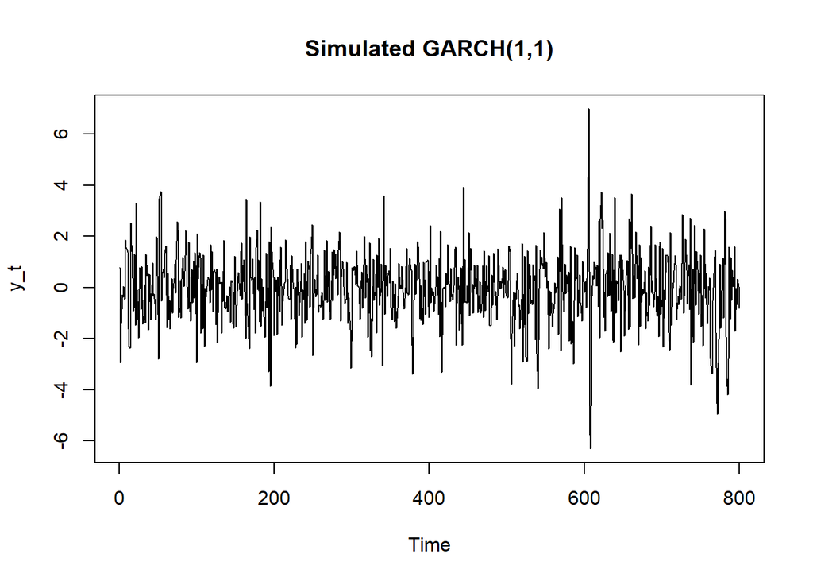

```r
T <- 800       # number of observations
omega <- 1
phi <- 0.5
k <- 0.5
mu <- 0

# Simulation
simulation <- simulator_garch(T, omega, phi, k, mu)

# Plot the series y_t:
y_t <- simulation$y_t_gen  # simulated time series
ts.plot(y_t, main="Simulated GARCH(1,1)")
```

We can plot the time varying parameter

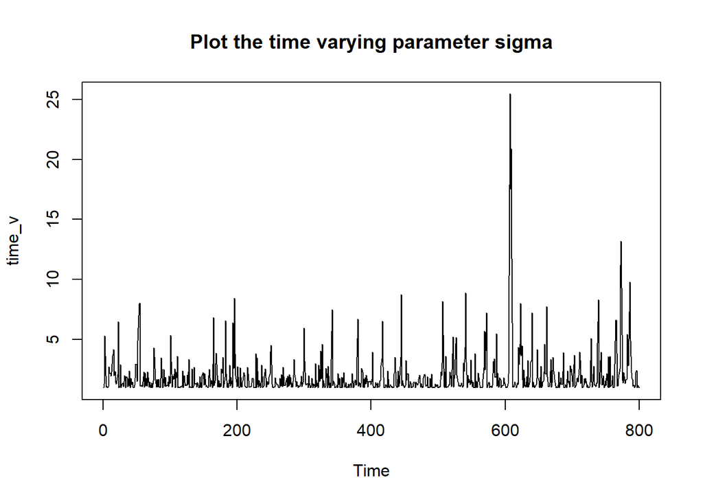

```r
time_v <- simulation$Dynamic_scale
ts.plot(time_v, main="Plot the time varying parameter sigma")
```

We can plot $u_t$ and $v_t$

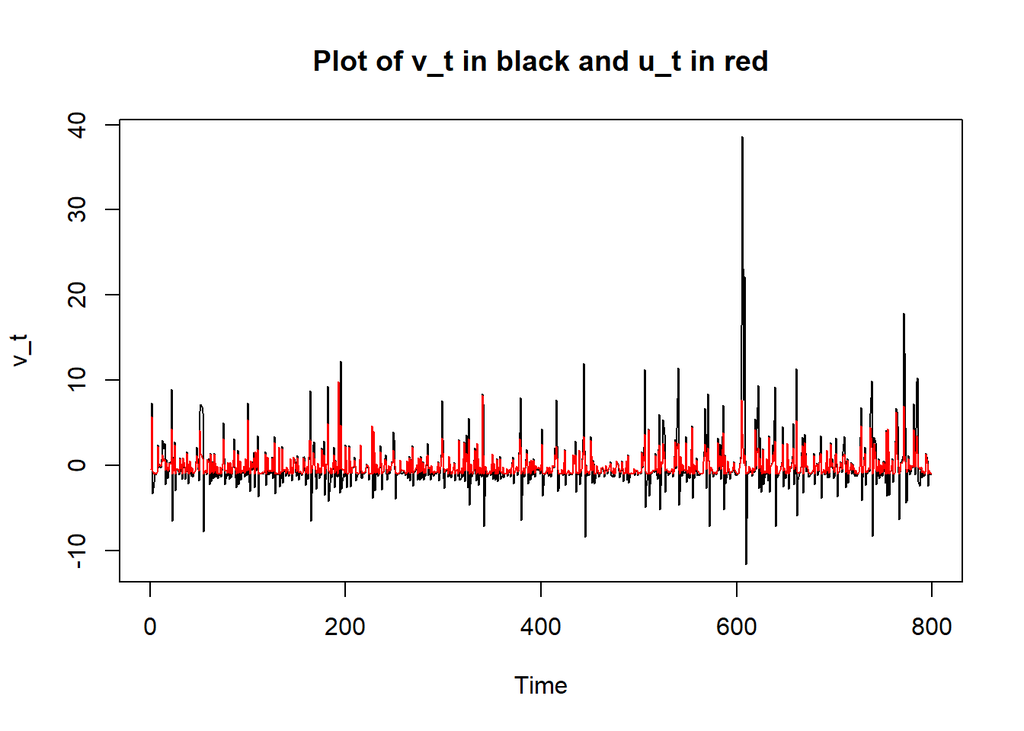

```r
v_t <- simulation$prediction_error
ts.plot(v_t, main="Plot of v_t in black and u_t in red")
u_t <- simulation$Innovation_u_t
lines(u_t, col="red")
```

Now to estimate the models I’m going to use the function defined in the R-score file uploaded in virtuale.

```r
uSTDT_uDCS_t <- function(y, sigma_t, varsigma, nu, log = TRUE){

  ulpdf <- (lgamma((nu + 1) / 2) - lgamma(nu / 2) - (1/2) * log(varsigma) -
              (1/2)  * log(pi * nu) - ((nu + 1) / 2) * log(1 + (y - sigma_t)^2 / (nu*varsigma) ))

  if(log != TRUE){
    ulpdf <- exp(ulpdf)
  }

  return(ulpdf)
}
```

```r
uDCS_t_model_filter <- function(y, theta){

  ###Take T
  T <- length(y)

  ###Define LogLikelihoods
  dloglik <- array(data = NA, dim = c(T))
  loglik  <- numeric()

  ###Parameter Selections Dynamic Scale
  omega <- theta[1]
  phi   <- theta[2]
  k     <- theta[3]

  varsigma <- theta[4]
  nu       <- theta[5]

  ###Define Dynamic Scale and Innovations

  u_t  <- array(data = NA, dim = c(T))
  sigma_t  <- array(data = NA, dim = c(T+1))

  ###Initialize Dynamic Scale
  sigma_t[1]   <- (omega)

  ###Initialize Likelihood
  dloglik[1] <- uSTDT_uDCS_t(y[1], sigma_t[1], varsigma = varsigma, nu = nu, log = TRUE)
  loglik     <- dloglik[1]

  for(t in 2:(T+1)) {
    ###Dynamic Scale Innovations
    u_t[t-1] <- mds_garch(y[t-1], sigma_t[t], varsigma)
    ###Updating Filter
    sigma_t[t]   <- omega + phi * sigma_t[t-1] + k * sigma_t[t-1] * u_t[t-1]

    if(t < (T+1)){
      ###Updating Likelihoods
      dloglik[t] <- uSTDT_uDCS_t(y[t], sigma_t = sigma_t[t], varsigma = varsigma, nu = nu, log = TRUE)
      loglik     <- loglik + dloglik[t]
    }
  }

  ######################
  ####### OUTPUT #######
  ######################
  sigma_t <- ts(sigma_t, start = start(y), frequency = frequency(y))
  u_t  <- ts(u_t, start = start(y), frequency = frequency(y))

  ###Make List
  out <- list(Dynamic_Scale= sigma_t,
              Innovation_u_t   = u_t,
              Log_Densities_i  = dloglik,
              Log_Likelihood   = loglik)

  return(out)
}
```

```r
interprete_uDCS_t_model <- function(dati, param){

  ###Take T
  T <- length(dati)

  ###Parameter Selections Dynamic Location
  omega <- param[1]
  phi   <- param[2]
  k     <- param[3]

  varsigma <- param[4]
  nu       <- param[5]

  ###Create a new vector with the parameters
  theta_new <- c(omega, phi, k, varsigma, nu)

  #------> Fitness Functions
  fitness <- uDCS_t_model_filter(dati, theta_new)$Log_Likelihood

  if(is.na(fitness) | !is.finite(fitness)) fitness <- -1e10
  if(fitness != fitness) fitness <- -1e10

  return(-fitness)
}
```

```r
garch_estimator <- function(dati, param){

  Start <- Sys.time()
  ###Take T
  T <- length(dati)

  ###Parameter Selections Dynamic Scale
  omega <- param[1]
  phi   <- param[2]
  k     <- param[3]

  varsigma <- param[4]
  nu       <- param[5]

  ###Create a vector with the parameters
  theta_st <- c(omega, phi, k, varsigma, nu)

  ###Take Bounds
  lower <- c(-Inf, -0.999, -2, 1e-05, 2.099)
  upper <- c( Inf,  0.999,  2, Inf, 300)

  #------> Optimize uDCS_t_model Filters w/L-BFGS-B
  #optimizer <- suppressWarnings(optim(par = theta_st, fn = interprete_uDCS_t_model,
  #                                    dati = dati, method = "L-BFGS-B",
  #                                    control = list(trace = 1), hessian = FALSE,
  #                                    lower = lower, upper = upper))

  #------> Optimize every uDCS_t_model Filters w/solnp := WAY faster than optim
  #optimizer <- suppressWarnings(Rsolnp::solnp(pars = theta_st, fun = interprete_uDCS_t_model,
  #                                            dati  = dati, control = list(trace = 1),
  #                                            LB = lower, UB = upper))

  #------> Optimize every uDCS_t_model Filters w/nlminb := WAY faster than optim
  optimizer <- suppressWarnings(nlminb(start = theta_st, objective = interprete_uDCS_t_model,
                                       dati  = dati, gradient = NULL,
                                       control = list(trace = 0), hessian = NULL,
                                       lower = lower, upper = upper))

  #------> Save the optimized parameters Dynamic Scale
  omega_opt <- optimizer$par[1]
  phi_opt <- optimizer$par[2]
  k_opt  <- (optimizer$par[3])

  varsigma_opt <- optimizer$par[4]
  nu_opt       <- optimizer$par[5]

  ###Create a vector with ALL the optimized parameters
  theta_opt <- c(omega_opt, phi_opt, k_opt, varsigma_opt, nu_opt)

  ###Create a list with ALL the optimized parameters
  theta_list <- list(omega = omega_opt,
                     phi = phi_opt,
                     k  = k_opt,
                     varsigma = varsigma_opt,
                     nu    = nu_opt)

  ######################
  ####### OUTPUT #######
  ######################

  #------> Some detail
  Elapsed_Time <- Sys.time() - Start
  print(paste("Elapsed Time: ", toString(Elapsed_Time)))

  ###Make List
  out <- list(theta_list = theta_list,
              theta      = theta_opt,
              optimizer  = optimizer)

  return(out)
}
```

```r
# Estimation
set.seed(1234)
mod_est <- garch_estimator(y_t, c(omega, phi, k, 1, 30))
```

```
## [1] "Elapsed Time:  11.262414932251"
```

```r
par<-mod_est$theta_list # estimated parameters
par
```

```
## $omega
## [1] -0.1295915
##
## $phi
## [1] -0.9739817
##
## $k
## [1] 0.09956153
##
## $varsigma
## [1] 1.395856
##
## $nu
## [1] 6.974205
```

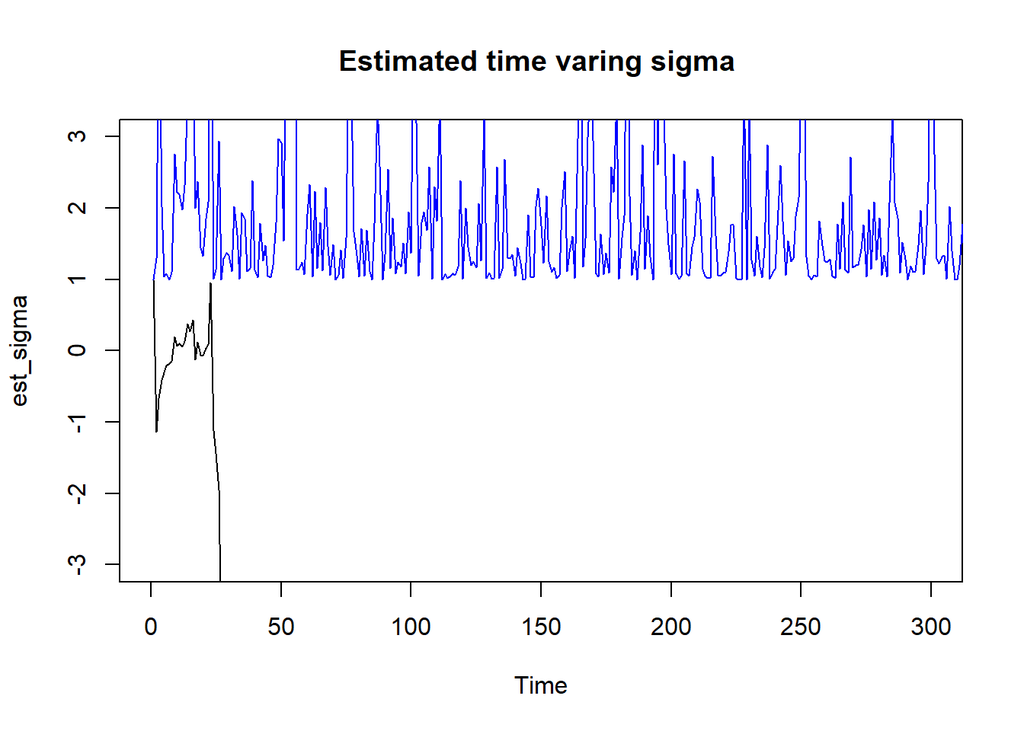

```r
#Estimation of the sigma
est_sigma<- array(data = NA, dim = T)
est_w<- array(data = NA, dim = T-1)
est_sigma[1] <- 1
for(t in 2:T) {
  est_w [t-1] <- (y_t[t-1]^2 / est_sigma[t-1]^2) - 1
  est_sigma[t]<- par$omega + (par$phi * est_sigma[t-1]^2)+ (par$k * est_sigma[t-1]^2 * est_w[t-1])
}
ts.plot(est_sigma, main="Estimated time varing sigma ", ylim=c(-3,3), xlim=c(0,300))
lines(time_v, col="blue")
```

Here in the last graph we can see that the estimated variance is far different from the simulated one (blue line). This is because they have been estimated with a different $z_t$ (t-Student and not Normal distribution).